# HW 5

Elaine Xu

11/14/2020

## Problem 1

Read in the data.

```r
homicide_df =
  read_csv("homicide_data/homicide-data.csv") %>%
  mutate(
    city_state = str_c(city, state, sep = "_"),
    resolved = case_when(
      disposition == "Closed without arrest" ~ "unsolved",
      disposition == "Open/No arrest"        ~ "unsolved",
      disposition == "Closed by arrest"      ~ "solved",
    )
  ) %>%
  select(city_state, resolved) %>%
  filter(city_state != "Tulsa_AL")
```

Let’s look at this a bit

```r
aggregate_df =
  homicide_df %>%
  group_by(city_state) %>%
  summarize(
    hom_total = n(),
    hom_unsolved = sum(resolved == "unsolved")
  )
```

Can I do a prop test for a single city?

```r
prop.test(
  aggregate_df %>% filter(city_state == "Baltimore_MD") %>% pull(hom_unsolved),
  aggregate_df %>% filter(city_state == "Baltimore_MD") %>% pull(hom_total)) %>%
  broom::tidy()
```

```
## # A tibble: 1 x 8
##   estimate statistic  p.value parameter conf.low conf.high method    alternative
##      <dbl>     <dbl>    <dbl>     <int>    <dbl>     <dbl> <chr>     <chr>
## 1    0.646      239. 6.46e-54         1    0.628     0.663 1-sample~ two.sided
```

Try to iterate ……..

```r
results_df =
  aggregate_df %>%
  mutate(
    prop_tests = map2(.x = hom_unsolved, .y = hom_total, ~prop.test(x = .x, n = .y)),
    tidy_tests = map(.x = prop_tests, ~broom::tidy(.x))
  ) %>%
  select(-prop_tests) %>%
  unnest(tidy_tests) %>%
  select(city_state, estimate, conf.low, conf.high)
```

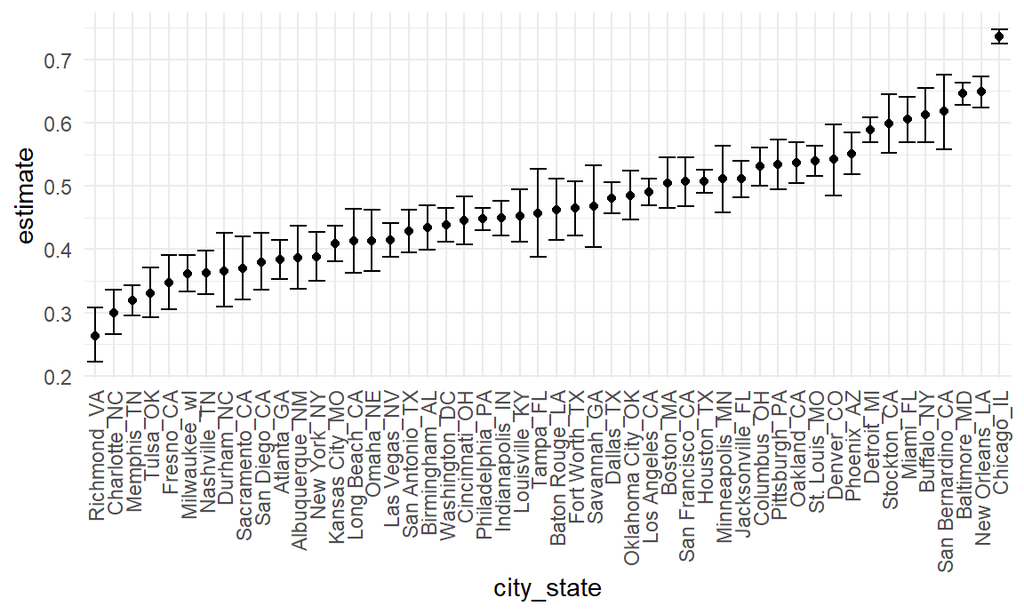

```r
results_df %>%
  mutate(city_state = fct_reorder(city_state, estimate)) %>%
  ggplot(aes(x = city_state, y = estimate)) +
  geom_point() +
  geom_errorbar(aes(ymin = conf.low, ymax = conf.high)) +
  theme(axis.text.x = element_text(angle = 90, vjust = 0.5, hjust = 1))
```

## Problem 2

Import one dataset

```r
path_df =
  tibble(
    path = list.files("./data"),
  ) %>%
  mutate(
    path = str_c("./data/", path),
    data = map(.x = path,~read_csv(.x)),
    arm = str_remove(path, ".csv"),
    arm = str_remove(arm, "./data/")) %>%
   separate(arm,c("arm","id"),sep = "_")%>%
  mutate(
    arm = ifelse(arm == "con", "control", "experiment")
  ) %>%
  unnest(data) %>%
  pivot_longer(
    week_1:week_8,
    values_to = "observation",
    names_to = "week"
  ) %>%
  mutate(week = str_remove(week, "week_")) %>%
  select(-path)

path_df
```

```
## # A tibble: 160 x 4
##    arm     id    week  observation
##    <chr>   <chr> <chr>       <dbl>
##  1 control 01    1            0.2
##  2 control 01    2           -1.31
##  3 control 01    3            0.66
##  4 control 01    4            1.96
##  5 control 01    5            0.23
##  6 control 01    6            1.09
##  7 control 01    7            0.05
##  8 control 01    8            1.94
##  9 control 02    1            1.13
## 10 control 02    2           -0.88
## # ... with 150 more rows
```

Spaghetti plot

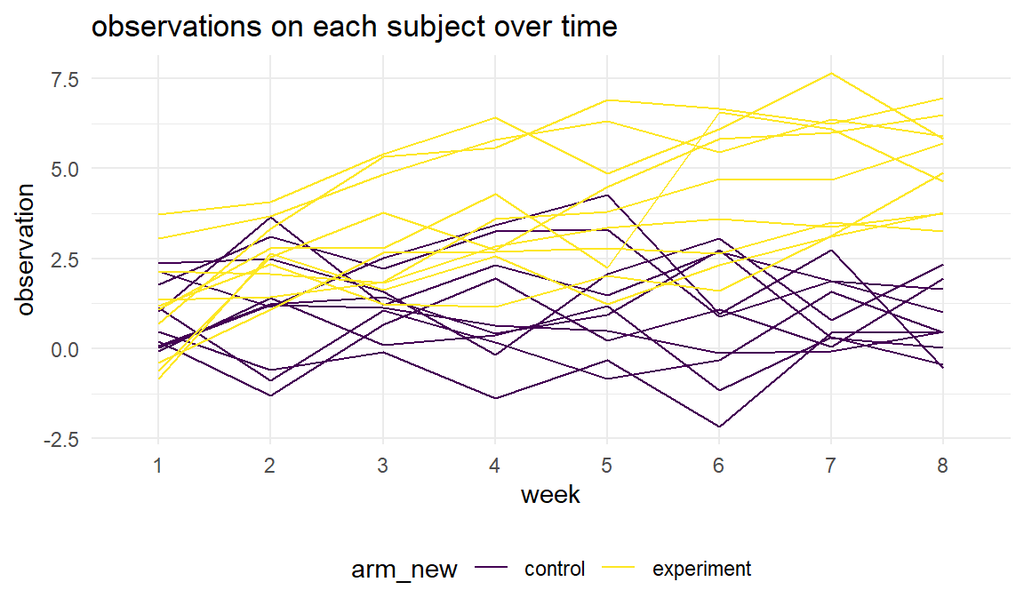

```r
spaghetti = path_df %>%
  mutate(arm_new = arm) %>%
  unite("subjects", c(arm, id))


ggplot()+geom_line(data = spaghetti, aes(x = week, y = observation, group = subjects, color = arm_new))+
  labs(title="observations on each subject over time")
```

From the graph, we can see that experiment groups have increased through the eight weeks, and it’s overall observation values are higher than control groups. Control groups’ trends didn’t have a very significant increase or decrease through these eight weeks.

## Problem 3

Function for t-test

```r
set.seed(33)

# n = 30
# sigma = 5

ttest = function(mu) {

  sim_data = tibble(
    x = rnorm(n = 30, mean = mu, sd = 5),
  )

  sim_data %>%
    summarize(
      t.test(x, mu = 0, conf.level = 0.95) %>%
    broom::tidy() )
}
```

generate 5000 datasets and repeat

```r
com_result = function(mu){

  rerun(5000, ttest(mu)) %>%
    bind_rows() %>%
    select(p.value, estimate)
}

# for mu = 0
com_result(0)
```

```
## # A tibble: 5,000 x 2
##    p.value estimate
##      <dbl>    <dbl>
##  1  0.584    0.449
##  2  0.701   -0.321
##  3  0.336    1.04
##  4  0.752    0.346
##  5  0.0409   2.10
##  6  0.467   -0.633
##  7  0.553   -0.543
##  8  0.951    0.0711
##  9  0.727   -0.297
## 10  0.344    0.843
## # ... with 4,990 more rows
```

```r
# for mu = 1,2,3,4,5,6

mu_result = tibble(
  mu = c(0,1,2,3,4,5,6)
) %>%
  mutate(output = map(.x = mu, ~com_result(.x))) %>%
  unnest(output) %>%
  select(mu, p.value)
```

plot showing the proportion of times the null was rejected and true mean

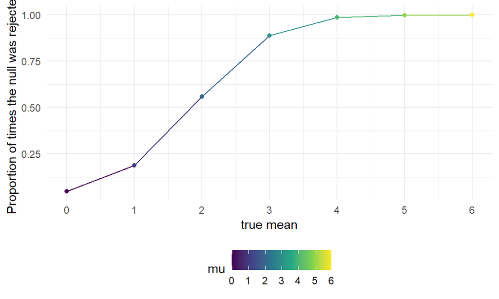

```r
porp_test = mu_result %>%
  group_by(mu) %>%
  filter(p.value < 0.05) %>%
  summarize(
    reject = n(),
    reject = reject/5000
  )

ggplot(data = porp_test, aes(x = mu, y = reject, color = mu)) + geom_line() + geom_point() +
  scale_x_continuous(limits = c(0,6), breaks = seq(0,6,1)) +
  labs(
    x = "true mean",
    y = "Proportion of times the null was rejected"
  )
```

**From the plot above we can see that when the $\mu$ is increasing, the power also increases. When true mean gets larger, the proportion of the null ($\mu = 0$) was rejected also gets larger and approaching to 1.**

plot showing the average estimate of $\hat{\mu}$ on the y axis and the true value of $\mu$ on the x axis.

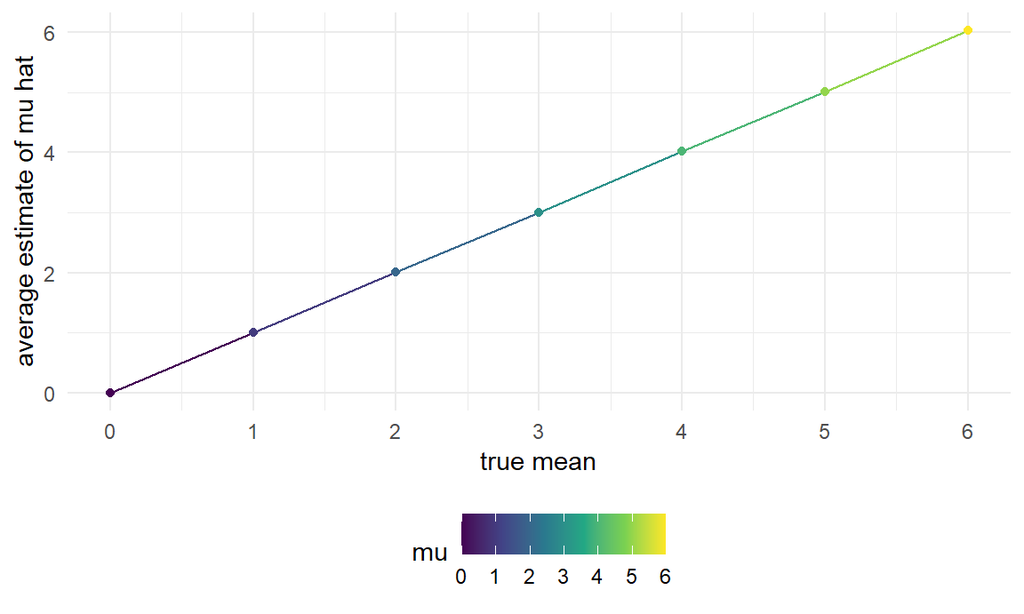

```r
ave_estimate = tibble(
  mu = c(0,1,2,3,4,5,6)
) %>%
  mutate(output = map(.x = mu, ~com_result(.x))) %>%
  unnest(output) %>%
  group_by(mu) %>%
  summarize(
    estimate = mean(estimate)
  )

ggplot(data = ave_estimate, aes(x = mu, y = estimate, color = mu)) + geom_line() + geom_point() +
  scale_x_continuous(limits = c(0,6), breaks = seq(0,6,1)) +
  labs(
    x = "true mean",
    y = "average estimate of mu hat"
  )
```

plot the average estimate of $\hat{\mu}$ only in samples for which the null was rejected on the y axis and the true value of $\mu$ on the x axis.

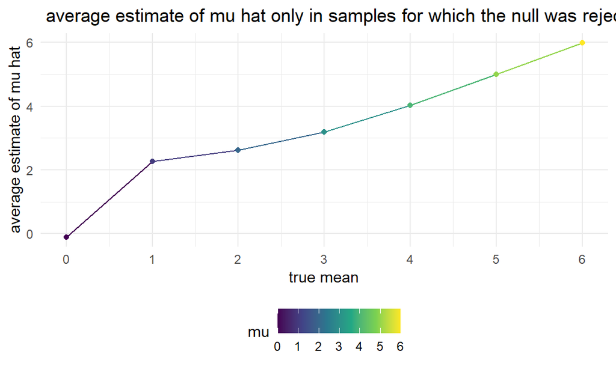

```r
sam_estimate = tibble(
  mu = c(0,1,2,3,4,5,6)
) %>%
  mutate(output = map(.x = mu, ~com_result(.x))) %>%
  unnest(output) %>%
  select(mu, p.value, estimate) %>%
group_by(mu) %>%
  filter(p.value < 0.05) %>%
  summarize(
    estimate = mean(estimate)
  )

ggplot(data = sam_estimate, aes(x = mu, y = estimate, color = mu)) + geom_line() + geom_point() +
  scale_x_continuous(limits = c(0,6), breaks = seq(0,6,1)) +
  labs(
    x = "true mean",
    y = "average estimate of mu hat",
    title = " average estimate of mu hat only in samples for which the null was rejected"
  )
```

**For $\mu$ = 0, 1, 2, we can see that the sample average $\hat{\mu}$ for which the null is rejected is different with the true mean. When $\mu$ increases ($\mu$ = 3, 4, 5, 6), the sample average $\hat{\mu}$ is getting closer and closer to the true mean, which is approximately equal to the true mean. This is because when true mean increases, the probability that the null hypothesis rejected also increases.**